# nlOmicAssoc

Lara Nonell

16/10/2018

# 1 Introduction

Association between omic data and continuous variables such as exposome expositions are in many cases not linear. Several methods are proposed to accomodate such relationship. In this package we propose and interface to the following methods:

- Multivariable Fractional Polynomial (MFP) model using stepwise,
- Exposome-wide association study (ExWASsp) with Natural Cubic Splines regressions,
- Generalized Additive Splines model using backfitting (GAM),
- Generalized Additive model using boosting (GAMboost),
- Regression Trees model using the algorithm Deletion Substitution Addition (partDSA),
- Random Forest using an implemented variable selection step (RF) and
- Neural Network with an implemented variable selection step (NNet)

The package provides tools to impute missing variables using *mice* and has functions to filter and obtain variable scores for each method as well and a comparison tool for the obtained results. Plots are also available for results.

# 2 Installation

Installation can be done directly from GitHub with the following instructions

if (!require(“devtools”)) install.packages(“devtools”)

devtools::install_github(“isglobal-brge/nlOmicAssoc”, force = TRUE)

# 3 Data

The input data for nlAssoc is the following:

- object: is the omic data set containing probes in rows and samples in columns. Can be a numeric ‘matrix’, an ‘ExpressionSet’ or a ‘SummarizedExperiment’
- covars: ‘data.frame’ with exposome variables (continuous).
- cores: number of cores to get to work in the case of parallelization (only for linux).

covars rownames should match to object columns

# 4 How to start: an example

## 4.1 Preparing data

```r
library(nlOmicAssoc)
library(BiocStyle)

library(brgedata)
library(rexposome)
library(mice)

# ExposomeSet
data("brge_expo")
head(expos(brge_expo))
```

```
##           Ben_p    Ben_t1    Ben_t2    Ben_t3     BPA_p    BPA_t1   BPA_t3
## x0001 0.6901979 0.7329199 0.7151049 0.6298382  1.904900  1.670000 2.139800
## x0002 0.8110416 0.7230410 0.8836752 0.8411245  4.662620  7.148515 2.176724
## x0003 0.6841825 0.3653689 0.8383091 0.8161064        NA        NA       NA
## x0004 0.8351608 0.8253160 0.7887700 0.8805178        NA        NA       NA
## x0005 0.6509367 0.7835652 0.4099737 0.7683659  3.184132  3.000000 3.368263
## x0006 0.5890706 0.3417259 0.6833910 0.7030494 13.205128 23.322580 3.087675
##          NO2_p   NO2_t1   NO2_t2   NO2_t3   PCB118    PCB138   PCB153
## x0001 30.98855 32.90669 32.10683 28.27852 8.118739 21.475727 54.80013
## x0002 37.12521 33.09701 40.45000 38.50225 6.871057 29.872524 49.81413
## x0003 29.19833 15.59257 35.77587 34.82834 5.618511  5.618511 12.12370
## x0004 33.99212 33.59143 32.10396 35.83821 6.537994 13.833786 25.94780
## x0005 28.42832 34.22060 17.90476 33.55680 6.990666 40.070881 60.09624
## x0006 26.93189 15.62347 31.24416 32.14292 6.129779  6.129779 14.70647
##          PCB180
## x0001 42.581181
## x0002 28.795677
## x0003  5.618511
## x0004 15.213384
## x0005 32.205936
## x0006 13.731941
```

```r
dim(expos(brge_expo))
```

```
## [1] 110  15
```

```r
head(pData(brge_expo))
```

```
##       Asthma Rhinitis Whistles  Sex      Age     CBMI
## x0001     no       no       no male 4.177960 16.64772
## x0002     no       no       no male 4.473648 15.54910
## x0003     no       no       no male 4.369610 15.76545
## x0004     no       no      yes male 4.331280 20.65343
## x0005     no       no       no male 4.306639 14.96169
## x0006     no       no       no male 5.560575 16.01160
```

```r
pat_expo<-rownames(pData(brge_expo))

# ExpressionSet
data("brge_gexp")
brge_gexp
```

```
## ExpressionSet (storageMode: lockedEnvironment)
## assayData: 67528 features, 100 samples
##   element names: exprs
## protocolData: none
## phenoData
##   sampleNames: x0001 x0002 ... x0139 (100 total)
##   varLabels: age sex
##   varMetadata: labelDescription
## featureData
##   featureNames: TC01000001.hg.1 TC01000002.hg.1 ...
##     TCUn_gl000247000001.hg.1 (67528 total)
##   fvarLabels: transcript_cluster_id probeset_id ... notes (11 total)
##   fvarMetadata: labelDescription
## experimentData: use 'experimentData(object)'
## Annotation:
```

```r
pat_gexp<-rownames(pData(brge_gexp))

# Common patients
common_pat<-intersect(pat_expo,pat_gexp)

# Needed objects

data_m<-exprs(brge_gexp)[,common_pat]
vars_df<-as.data.frame(expos(brge_expo)[common_pat,])

# Missing values in variables
pNA <- function(x){sum(is.na(x))/length(x)}
which(apply(vars_df,1,pNA)>(70/100))
```

```
## x0031
##    31
```

```r
# Final vars_df object
vars_df<-vars_df[!(rownames(vars_df) %in% c("x0031")),]
```

## 4.2 Applying the model

Once data are prepared, is time to call the method. Methods should be called using the following names: * mfp: Multivariable Fractional Polynomial model using stepwise, * exwassp: Exposome-wide association study with Natural Cubic Splines regressions, * gam: Generalized Additive Splines model using backfitting, * gamboost: Generalized Additive model using boosting, * partdsa: Regression Trees model using the algorithm Deletion Substitution Addition, * rforest: Random Forest using an implemented variable selection step and * nnetwork: Neural Network with an implemented variable selection step

as an example we will test Multivariable Fractional Polynomial (MFP) model using stepwise.

```r
n<-200

brge.mfp <- nlOmicAssoc(object = data_m[1:n,],
                      covars = vars_df,
                      model = "mfp",
                      imp_method = 'pmm',
                      perc_imp = 70,
                      cores = 1L,
                      verbose = FALSE)
```

```
## Missing values will be imputed using function specified in imp.method of the mice package
## Imputing missing variables through package mice
##
```

## 4.3 nlAssoc class

```r
names(brge.mfp)
```

```
## [1] "table"         "selected_vars" "analysis_vars" "final_formula"
## [5] "call"          "object"        "covars"        "filter"
```

```r
brge.mfp
```

```
## Object of class nlAssoc
## Number of assessed probes: 200
## Number of assessed variables: 15
##
## Call:
## nlOmicAssoc(object = data_m[1:n, ], covars = vars_df, model = "mfp",
##     imp_method = "pmm", perc_imp = 70, cores = 1L, verbose = FALSE)
```

## 4.4 Summary

Summary function gives information about the call and the results obtained and will help in following steps to filter results.

```r
summary(brge.mfp)
```

```
## Object of class nlAssoc
## Number of assessed probes: 200
## Number of assessed variables: 15
## Number of probes at an adjusted.p < 0.05: 45
## Number of probes at a p < 0.01: 45
## Number of probes at a p < 0.05: 45
## Top scoring variables : BPA_t1,PCB153,BPA_p,BPA_t3,NO2_p
##
## Call:
## nlOmicAssoc(object = data_m[1:n, ], covars = vars_df, model = "mfp",
##     imp_method = "pmm", perc_imp = 70, cores = 1L, verbose = FALSE)
```

## 4.5 Filtering results

Results can be filtered using different parameters as the FDR adjusted p-value (default)

```r
brge.mfp.f <- getSignif(brge.mfp, threshold = 0.05)
summary(brge.mfp.f)
```

```
## Filtered nlAssoc object using adj.p with threshold 0.05
## Number of filtered probes: 45
## Number of assessed probes: 200
## Number of assessed variables: 15
```

## 4.6 Plotting

Plots are obtained for each probe in the gene expression data set. A pdf is created with the comparison between the real data and the predicted by mfp in this case.

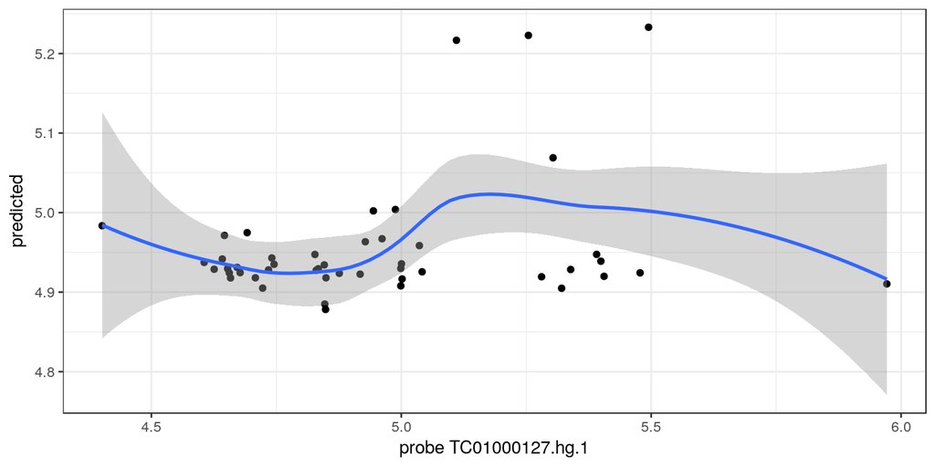

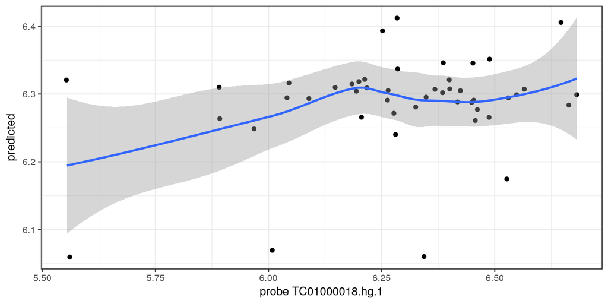

```r
#sembla que no xuta...
plot(brge.mfp.f, top.probes=2)
```

## 4.7 Plotting mfp single results

For the special case were the model applied is mfp, partial effects of a single model can be visualized with function plot.single.mfp. This funcion allows the adjustment of x and y limits in the plot.

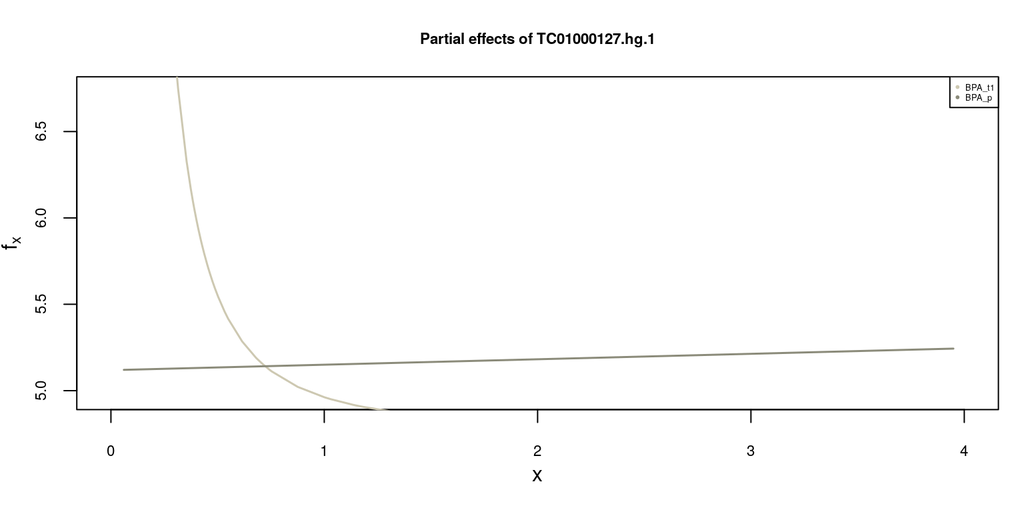

```r
#sembla que no xuta...
plot.single.mfp(brge.mfp.f, probe=brge.mfp.f$table$probe[1],xlim=c(0,4))
```

## 4.8 Scoring variables

To discern the most important variables in a data set, a scoring measure was defined as the total number of times the variable has been selected divided by the number of total tests performed. This can be obtained by calling funcion scoreVars

```r
scoreVars(brge.mfp)
```

```
##
## BPA_t1 PCB153  BPA_p BPA_t3  NO2_p NO2_t1 NO2_t3 Ben_t2 NO2_t2 PCB138 Ben_t1
##  0.090  0.040  0.030  0.020  0.020  0.020  0.020  0.015  0.015  0.015  0.010
## Ben_t3  Ben_p PCB180
##  0.010  0.005  0.005
```

# 5 Compare results among methods

To compare among models the GAM model and ExWAS will also be applied.

GAM model.

```r
brge.gam <- nlOmicAssoc(object = data_m[1:n,],
                      covars = vars_df,
                      model = "gam",
                      imp_method = 'pmm',
                      perc_imp = 70,
                      cores = 1L,
                      verbose = FALSE)
```

```
## Missing values will be imputed using function specified in imp.method of the mice package
## Imputing missing variables through package mice
##
```

```r
summary(brge.gam)
```

```
## Object of class nlAssoc
## Number of assessed probes: 200
## Number of assessed variables: 15
## Number of probes at an adjusted.p < 0.05: 35
## Number of probes at a p < 0.01: 35
## Number of probes at a p < 0.05: 35
## Top scoring variables : Ben_t2,PCB153,PCB180,BPA_t1,NO2_t3
##
## Call:
## nlOmicAssoc(object = data_m[1:n, ], covars = vars_df, model = "gam",
##     imp_method = "pmm", perc_imp = 70, cores = 1L, verbose = FALSE)
```

ExWAS model.

```r
brge.exwas <- nlOmicAssoc(object = data_m[1:n,],
                      covars = vars_df,
                      model = "ewas",
                      imp_method = 'pmm',
                      perc_imp = 70,
                      cores = 1L,
                      verbose = FALSE)
```

```
## Missing values will be imputed using function specified in imp.method of the mice package
## Imputing missing variables through package mice
##
```

```r
summary(brge.exwas)
```

```
## Object of class nlAssoc
## Number of assessed probes: 200
## Number of assessed variables: 15
## Number of probes at an adjusted.p < 0.05: 14
## Number of probes at a p < 0.01: 14
## Number of probes at a p < 0.05: 14
## Top scoring variables : BPA_t1,PCB153,Ben_t2,Ben_p,NO2_p
##
## Call:
## nlOmicAssoc(object = data_m[1:n, ], covars = vars_df, model = "ewas",
##     imp_method = "pmm", perc_imp = 70, cores = 1L, verbose = FALSE)
```

Comparison among the three models. Parameters param, comp and threshold allow to filter each set results by different parameters and compare among them.

```r
list.meth<-list(brge.exwas,brge.gam,brge.mfp)
compareMethods(list.meth,filter=T,threshold=0.05)
```

```
##      [,1] [,2] [,3]
## [1,]   14    3   13
## [2,]   NA   35    9
## [3,]   NA   NA   45
```